# stats & data notes

# modeling

three kinds of variability: 1. measurement error 2. demographic stochasticity *3. environmental stochasticity* *process variability or error

three kinds of statistical inference: 1. classical frequentist 2. maximum likelihood estimation 3. Bayesian

# lecture one

## probability

**event**: something that does or does not occur per **trial**: observation, specimen, “experiment”

**probability**:

P(A): probability event A occurs n: total number of trials $n_A$: total number of trials in which A occurs P(A) = $\frac{n_A}{n}$, provided n is sufficiently large

$$P(A) = \lim_{x\to\infty} (\frac{n_A}{n})$$

endangered orchids example:

we found 5 plants this year and came back to look at them next year

1. plant #1 is alive and has flowers and leaves
2. plant #2 is alive but only has leaves
3. plant #3 is alive but only has leaves
4. plant #4 is alive but only has leaves
5. plant #5 is dead!

80% probability plant lives through one year 20% probability plant (lives and) flowers each year 25% probability plant flowers, if it lives (flowers|living)

## sampling

must be **representative** and **independent** **random**: gold standard of statistics **stratified**: different groups represented **haphazard**: everything you see, *etc.*

# lecture two

## probability (again)

think of all possible events as circle, probability of events are subsumed circles

**OR**: $P(A+B)$ **AND**: $P(A,B)$ **conditional**: $P(B|A) = P(A,B)/P(A)$ **mutually exclusive**: $P(A,B) = 0; P(B|A) = 0$ **OR rule**: $P(A+B) = P(A) + P(B)$ **independent**: $P(B|A) = P(B); P(A|B) = P(A)$ **AND rule**: $P(A,B) = P(A)*P(B)$

probabilities of individual outcomes using estimated parameters from above: 1. plant #1 - $P(s)*P(f) = 0.8*0.25 = 0.2$ 2. plant #2 - $P(s)*(1-P(f)) = 0.8*0.75 = 0.6$ 3. plant #3 - $P(s)*(1-P(f)) = 0.8*0.75 = 0.6$ 4. plant #4 - $P(s)*(1-P(f)) = 0.8*0.75 = 0.6$ 5. plant #5 - $(1 - P(s)) = 0.2$

& probability of overall outcome, using estimated and other parameters: H1: $P(s=0.8,f=0.25) = 0.2*0.6*0.6*0.6*0.2 = 0.00864$ H2: $P(s=0.6,f=0.4) = 0.24*0.36*0.36*0.36*0.4 = 0.00448$ H3: $P(s=0.8,f=0.25,n=10) = 0.2*0.2*0.6*0.6*0.6*0.6*0.6*0.6*0.2*0.2 = 0.00007465$ H4: $P(s=0.6,f=0.4,n=10) = 0.24*0.24*0.36*0.36*0.36*0.36*0.36*0.36*0.4*0.4 = 0.00002006$

probability of large dataset is smaller than probability of small dataset by nature

## likelihood

likelihood L of hypothesis H given data R is proportional to P(R|H), constant of proportionality k being arbitrary (but specific to particular dataset; Edwards 1972)

$$L(H|R) = k*P(R|H)$$

likelihood ratio is our primary method of comparing models: $L(P(s)=0.8,P(f)=0.25/R) = k*0.00864$ $L(P(s)=0.6,P(f)=0.4/R) = k*0.00448$ $L(H1)/L(H2) = k*0.00864/k*0.00448$ = 1.93 “times more likely” $L(H3)/L(H4) = k2*0.00007465/k2*0.00002006$ = 3.72 “times more likely”

things to remember:

1. likelihood decreases as sample size increases constant of proportionality specific to particular dataset AND SO ONLY COMPARE MODELS FIT TO SAME DATASET
2. likelihood ratio (relative support) increases as sample size increases arbitrary parameters always worse than ones estimated from data (but sometimes not by that much)
3. (log) likelihoods often taken from log-transformed probabilities to avoid dealing with tiny numbers for typical (large) data sets

```r
(p_H3 <- log(0.00007465))
```

```
[1] -9.5027
```

```r
(p_H4 <- log(0.00002006))
```

```
[1] -10.81678
```

```r
p_H3/p_H4
```

```
[1] 0.8785145
```

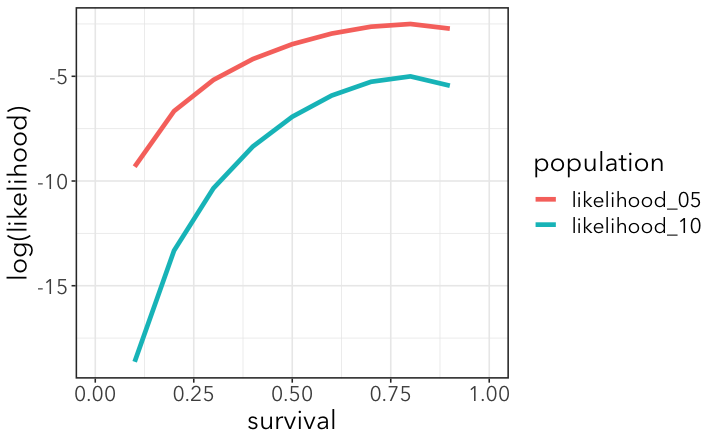

```r
plantguy <- data.frame(survival = c(0.1, 0.2, 0.3, 0.4, 0.5, 0.6, 0.7, 0.8, 0.9))
plantguy$likelihood_05 <- plantguy$survival^4*(1-plantguy$survival)
plantguy$likelihood_10 <- plantguy$survival^8*(1-plantguy$survival)^2

plantguy <- plantguy %>% gather(population, likelihood, -survival)

ggplot(plantguy, aes(x = survival, y = log(likelihood), color = population)) +
  geom_line(size = 1.5) + xlim(0,1)
```

events can be independent and mutually exclusive ONLY if the probability of one is zero: **mutually exclusive**: $P(A,B) = 0$ **independent**: $P(A,B) = P(A)*P(B)$ ERGO: $P(A)*P(B) = 0$

#lecture three

##log transformation

1. exponential transformation undoes log transformation, and vice-versa

```r
A=5
log(exp(A))
```

```
[1] 5
```

```r
exp(log(A))
```

```
[1] 5
```

2. log transformation converts × and % into + and -

$ln(AB)=ln(A)+ln(B)$ $ln(A/B)=ln(A)-ln(B)$ $ln(A^C) = C*ln(A)$

```r
C * log(A)
```

```
[1] 4.828314
```

log-transformed likelihood ratios –> differences in likelihoods: can be back-transformed to calculate relative support in absolute sense $P(A,B)=P(A)*P(B)$ $ln(P(A,B))=ln(P(A))+ln(P(B))$

```r
#to get likelihood...
flower = (0.24)^2
leaves = (0.36)^6
dead = (0.4)^2
all = flower*leaves*dead
all
```

```
[1] 2.006123e-05
```

```r
#to get log likelihood...
2*log(0.24)+6*log(0.36)+2*log(0.4)
```

```
[1] -10.81672
```

```r
log(all)
```

```
[1] -10.81672
```

##Bayes theorem

three major conceptual points: 1. use data to estimate parameters (probabilities) 2. calculate probability of data given particular model (parameters) 3. calculate likelihood (relative support) of model, given data

NOW 4. calculate probability a model is “true”, given data

– Bayes came up with the formula to do it in the 1700s!

probability of model given data equals probability of data given model multiplied by probability of model, divided by probability of data

$$P(model|data)=\frac{P(data|model)*P(model)}{P(data)}$$

P(data|model) calculated using axioms of probability

P(model) before we collect any data: 1. uninformative prior probability (if j models, = 1/j) 2. informative prior probability… also exists?!

P(data), assuming we’ve searched over all (n) models:

$$P(data) = \sum_{j = 1}^nP(data|model_j)*P(model_j)$$
this definition makes P(data) constant for given set of data! and makes Bayes theorum resemble Edwards’ definition of likelihood

$$P(model|data)=\frac{P(data|model)*{(1/j)}}{c}
\\
L(H|R) = k*P(R|H)
\\
k = 1/jc$$
$P(model|data) = L(H|R)$ IF $k = \frac{1}{n*c}$ (L = likelihood)

ERGO: in Bayesian analysis, explicitly estimate constant relating the probability of model given data  
an absolute measure of support for a model!?!?! – IF we say we have searched all possible models in likelihood analysis, we restrict our analyses to relative support among models